# Forelesning ØKB1115 Makroøkonomi: Del I Konjunktursvingninger - liten åpen økonomi

## Grunnleggende bakgrunnskunnskaper

### Stabiliseringsmål for en åpen økonomi

- Intern balanse (lukke produksjonsgapet):

\[(Y-\overline{Y})=0\]

- Ekstern balanse (rimelig nivå på utenlandsgjelden - gjelden skal kunne betjenes uten problemer)

### Tre fundamentale endringer fra en lukket økonomi

#### (1) Handel med utlandet

\[AE \equiv C+I+G+NX\] \(NX\) er nå inkludert i definisjonen for aggregert etterspørsel

NX er definert som eksport \((EX)\) minus import \((R\cdot IM)\) målt i enheter av det innenlandske godet:

\[NX=EX−R\cdot IM \text{ }\] Realvalutakursen \(R=\frac{E\cdot P^{*}}{P}\) (prisforholdet mellom utenlandske og innenlandske goder målt i enheter av det innenlandske gode) sørger her for at alt blir målt i enheter av det innenlandske godet.

#### (2) Fast eller flytende kurs

Renteparitetsbetingelsen

\[(1+i_{t+1})=(1+i_{t+1}^{*})\frac{E_{t+1}^{e}}{E_{t}}\] Likevektsbetingelse som forteller oss at den forventede avkastningen er lik mellom å investere i inn- og utland.

Her er \(i_{t+1}\) innenlandsk avkastning, \(i_{t+1}^{*}\) utenlands avkastning, \(E_{t}\) er (nominelle) prisen i dag per énhet av utenlandsk valuta og \(E_{t+1}^{e}\) den forventede valutakursen én periode frem i tid.

#### (3) Utenriksregnskapet (BoP)

\[BP = CA + CU + OR=0\]

\(CU=\text{Driftsregnskapet}\).

Består av nettoeksport (NX), pluss nettofinansinntekter(aksjer og obligasjoner) og nettoverføringer

\(CA=\text{Kapitalregnskapet}\)

Nettoendringer i fordringer og gjeld overfor utlandet

\(OR=\text{Endringer i sentralbankens valutareserver}\)

Vil øke (reduseres) dersom fastkursprisen er svakere (sterkere) enn det som markedet er villig til å betale

## Mundell-Fleming modellen

### Adferdsligninger

#### Husholdninger og bedrifter

Husholdningene import (\(IM\)) av utenlandske goder er gitt ved

\[IM= -m_{1}R + m_{2}Y \]

Bedriftenes eksport (\(EX\)) av innenlandske goder er gitt ved

\[EX=x_{1}R + x_{2}Y^{*} \]

Legger til grunn i dette kurset at priseffekten dominerer innteksteffekten ([Marshall-Lerner betingelsen](https://en.wikipedia.org/wiki/Marshall%E2%80%93Lerner_condition) ):

\[\frac{\Delta NX}{\Delta R}= \underset{priseffekt}{x_{1}} - \underset{inntektseffekt}{IM} + \underset{priseffekt}{m_{1}R} > 0 \\~ \text{ (i dette kurset antar vi at dette holder, men i praksis vil det ta litt tid)}\]

#### Offentlige myndigheter (instruering) og sentralbanken (implementering)

Myndighetene kan velge mellom fast eller flytende kurs:

- Fast \[i =i^{*} + rp\]

Anser markedsaktørene faskursregimet som troverdig, har vi at \(E=E^{e} \Rightarrow rp=0\)

- Flytende

\[E=\frac{(1+i^{*})}{(1+i)}E^{e}\]

## Mundell-Fleming modellen under fast kurs

Viser den samtidige likevekten i gode-, penge- og valutakursmarkedet under fast kurs

### Godemarkedet

\[Y = \frac{1}{1-c(1-t) + R\cdot m_{2}} \left [ \overline{C} + \overline{I} - b\cdot \overline{i} + \overline{G} + EX \\~ + R^{2}\cdot m_{1} \right]\]

### Pengemarkedet

\[kY -hi = \overline{M}/P\]

### Valutakursmarkedet

\[i =i^{*} + rp\]

**Formelt**

\[i =i^{*} + rp \text{ BoP-kurven}\]

**Grafisk**

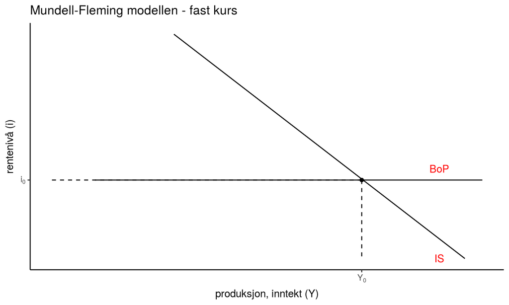

### Komparativ statikk (skiftanalyse)

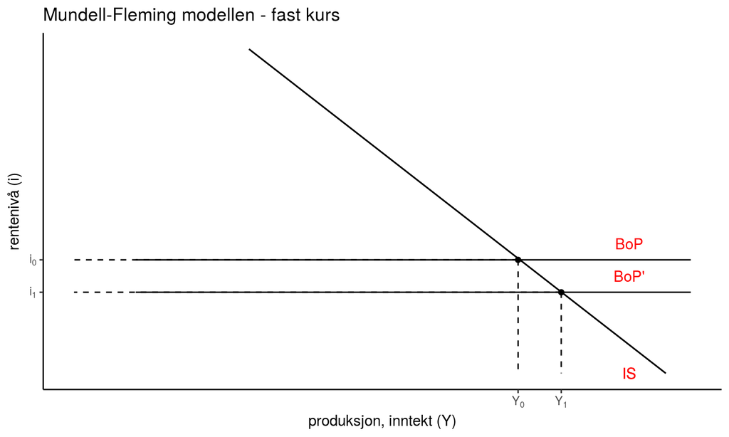

### Stabiliseringspolitikk (G og T)

Eks. reduksjon i offentlig utgifter (\(\overline{G}<0\))

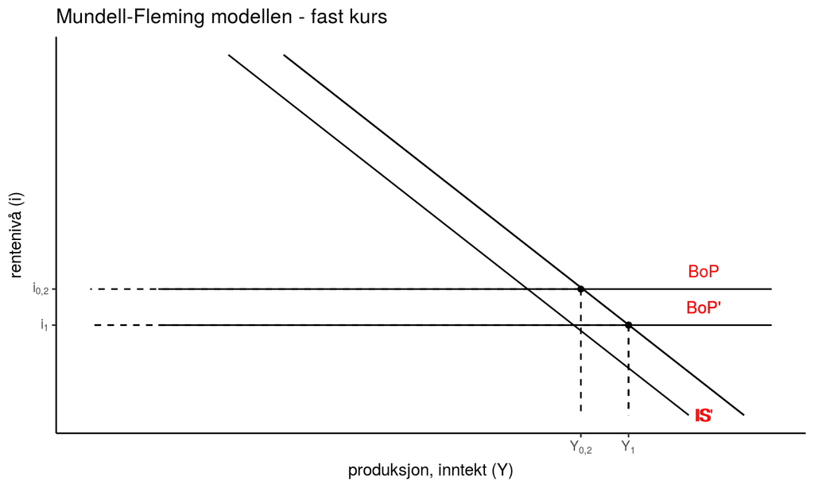

Merk: Under fast kurs er renta bundet til å holde fastkursen stabil, det gjør at finanspolitikk (endring i offentlige utgifter og skatter) står igjen som de *eneste* virkemidlene til å stabilisere konjunktursvingningene

## Mundell-Fleming modellen under flytende kurs

Viser den samtidige likevekten i gode-, penge- og valutakursmarkedet under flytende kurs.

### Godemarkedet

\[Y = \frac{1}{1-c(1-t) + R\cdot m_{2}} \left [ \overline{C} + \overline{I} - b\cdot \overline{i} + \overline{G} + EX \\~ + R^{2}\cdot m_{1} \right]\]

### Pengemarkedet

\[kY -hi = \overline{M}/P\]

### Valutakursmarkedet

\[E=\frac{(1+i^{*})}{(1+i)}E^{e}\]

### Valuta- og godemarkedet

For å lette den grafisk analysen, ønsker vi å finne et uttrykk som gir oss den samtidige likevekten i valuta- og godemarkedet. Vi starter først med å skrive (på generell form) den nominelle valutakursen som \(E=E(\underset{(-)}{i},\underset{(+)}{i^{*}},\underset{(+)}{E^{e}})\). Setter vi så denne funksjonen inn i definisjonen for realvalutakursen får vi

\[R=\frac{E(i,i^{*},E^{e})\cdot P^{*}}{P}=R(\frac{P^{*}}{P},i,i^{*},E^{e})\]

Ved å sette det generelle utryyket for \(R\) inn likevektsbetingelsen for godemarkedet, finner vi den samtidige likevekten i gode- og valutakursmarkedet:

\[Y = \frac{1}{1-c(1-t) + R(\frac{P^{*}}{P},i,i^{*},E^{e}) \cdot m_{2}} \left [ \overline{C} + \overline{I} \\~ - b\cdot \overline{i} + \overline{G} + EX(R\Big(\frac{P^{*}}{P},i,i^{*},E^{e}\Big)) + R^{2}(\frac{P^{*}}{P},i,i^{*},E^{e})\cdot m_{1} \right]\]

Dersom Marhsall-Lerner betingelsen holder, er det mulig å vise (ikke pensum i dette kurset) at IS-BoP-kurven (flytende kurs) er slakere enn IS-kurven (fast-kurs)

**Formelt**

\[\underset{IS-BoP-kurven ( flytende-kurs)}{\frac{\Delta Y}{\Delta \overline{i}}} < \underset{IS-kurven (fast-kurs)}{\frac{\Delta Y}{\Delta \overline{i}}} < 0 \]

**Grafisk**

Viser den samtidige likevekten i gode-, penge- og valutakursmarkedet (flytende kurs)

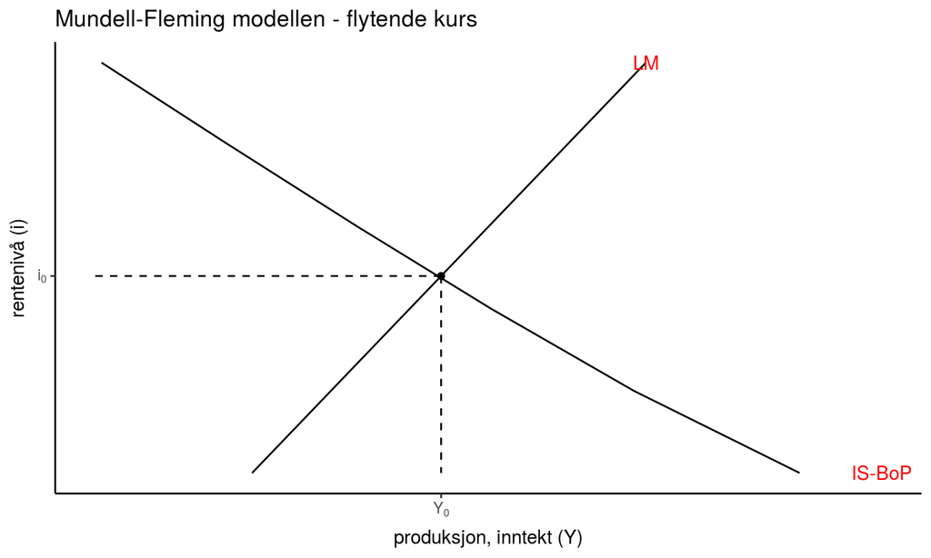

### Komparativ statikk (skiftanalyse)

Økning i offentlige utgifter (\(\overline{G}>0\))

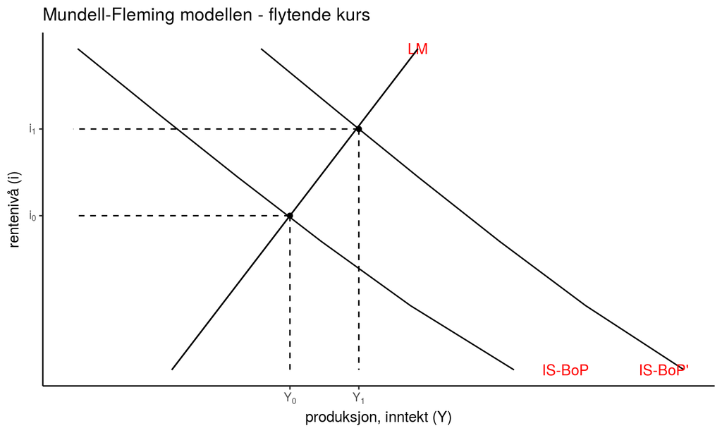

### Stabiliseringspolitikk (M/(i), G og T)

Eks. reduksjon i pengmengden (\(\overline{M}<0\))

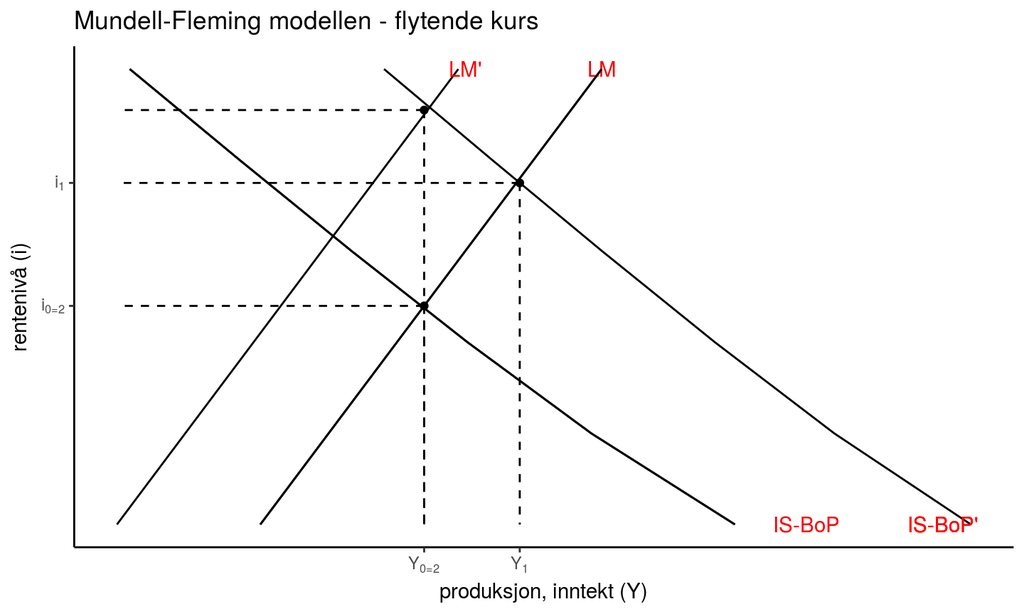

Merk: I motsetning til under fastkurs, har man under flytende kurs muligheten til å benytte pengepolitikken til å stabilisere konjunktursvingningene. I Norge i dag er dette rådende pengepolitiske regimet, mens vi på 90-tallet og i etterkrigsperioden praktiserte ulike former for fastkursregimer (ovenfor veid snitt av europeiske valutaer).

## AD-AS modellen for en åpen økonomi

### AD- likningen under fast og flytende kurs

Utleder AD-kuren ved å se på effekten av prisreduksjon (\(\Delta P<0\)) i Mundell-Fleming modellen under fast og flytende kurs

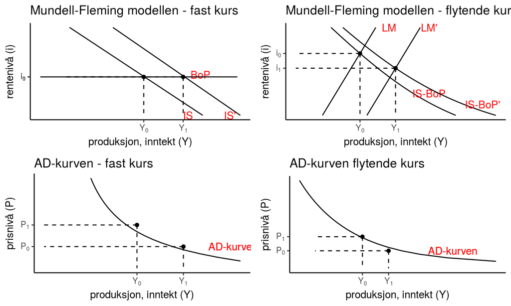

Helningen på AD-kurven styres av:

- Fast kurs
  - Forbedrer nettoeksporten gjennom en depresiering av realvalutakursen (Marshall-Lerner betingelsen)
- Flytende kurs
  - Forbedrer nettoeksporten gjennom en depresiering av realvalutakursen (Marshall-Lerner betingelsen)
  - Høyere realpengemenge reduserer renta som igjen øker produksjonen (samme som under lukket økonomi)

### AS-kurven

Adferdsligningene er de samme som for en lukket økonomi

## AD-AS modellen for en åpen økonomi med fast valutakurs

Viser den samtidige likevekten i gode-, penge-, og valutakurs- og arbeidsmarkedet

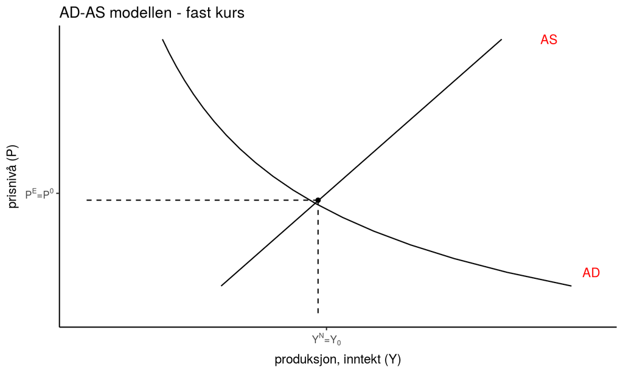

- Produksjonen er her lik det naturlige produksjonsnivået \(Y^{N}\) og prisnivået \(P^{N}\) er forenlig med det nivået på realvalutakursen \(R^{E}=\frac{\overline{E}\cdot P^{*}}{P^{E}} \Rightarrow NX = 0 \Leftrightarrow IM = EX\)

### Komparativ statikk (skiftanalyse)

#### Kort sikt (del1): intern balanse

- Statiske prisforventninger (\(P^{e}\) er eksogen) Økte offentlige utgifter, \(\overline{G}>0\)

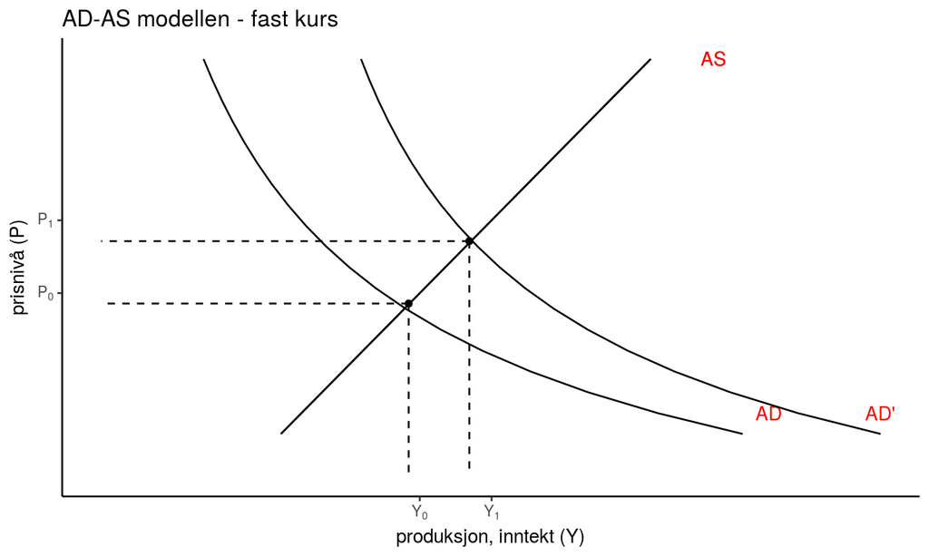

#### Mellomlang sikt (del1): intern balanse

- Korrekte prisforventninger (\(P^{e}=P\))

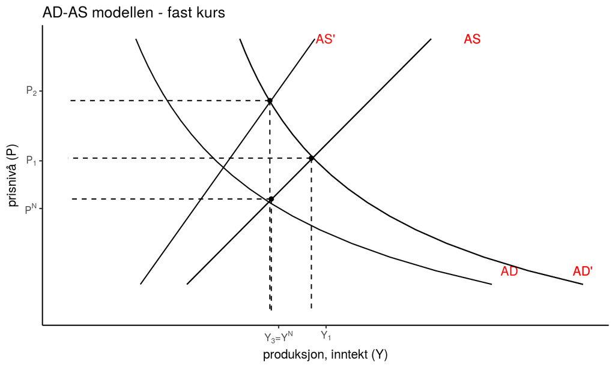

Tolkning: Korrekte prisforventninger fører til et negativt skift i AS-kuren helt produksjonen og arbeidsledigheten er tilbake til sitt naturlige likevektsnivå.

- Sentralt poeng: Korrekte prisforventninger medfører at modellen innehar selvkorrigerende mekanismer mot intern balanse
- Men ikke forenlig med målet om ekstern balanse. Prisnivået \(P_{3}\) sikrer nivået på realvalutakursen \(R_{3}=\frac{\overline{E}\cdot P^{*}}{P_{3}} \Rightarrow NX < 0 \Leftrightarrow IM > EX\). Noe som gjør nettogjelden overfor utlandet øker (jmf. utenriksregnskapet).
- Dersom offentlige myndigheter ikke gjør noe med denne situasjonen (\(\Delta G<0\) eller \(\Delta T >0\)), vil markedskreftene etterhvert løse situasjonen på egenhånd gjennom økt risikopremie (\(\Delta rp> 0\)).

#### Kort sikt (del2): intern og ekstern balanse

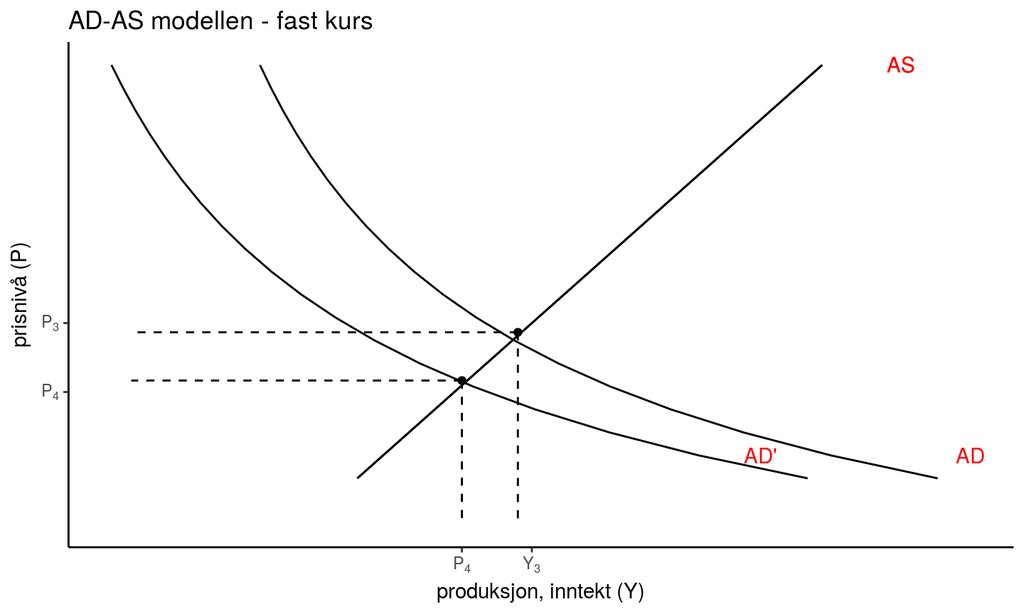

#### Mellomlang sikt (del2): intern og ekstern balanse

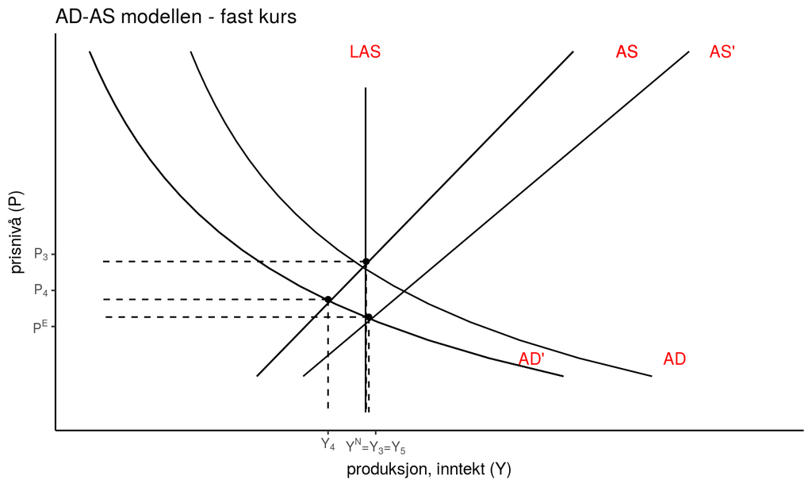

### AD-AS modellen under flytende valutakursregime

Antar her at målet om ekstern balanse automatisk blir sikret gjennom endringer i valutakursforventningene (\(E^{e}\)). Analysen vil derfor ha lik form (isomorfisk) som for en lukket økonomi.

### Flytende kurs vs. fast kurs?

> **The argument for a flexible exchange rate is, strange to say, very nearly identical with the argument for daylight savings time.** Isn't it absurd to change the clock in summer when exactly the same result could be achieved by having each individual change his habits? All that is required is that everyone decide to come to his office an hour earlier, have lunch an hour earlier, etc. But obviously **it is much simpler to change the clock that guides all than to have each individual separately change his pattern of reaction to the clock**, even though all want to do so. **The situation is exactly the same in the exchange market**. **It is far simpler to allow one price to change, namely, the price of foreign exchange, than to rely upon changes in the multitude of prices that together constitute the internal price structure.**
- Milton Friedman *The Case for Flexible Exchange Rates*, page 173

[figure not shown]